# Tug1 KO vs WT (Embryonic)

- other heatmap labels (csHeatmap)
- cache gsea and overlap figure!!
- tracks
- should import litter info

# Design Overview

This file shows the wt-v-ko comparison for Tug1.

Cuff overview:

```
## CuffSet instance with:
##   2 samples
##   26754 genes
##   77524 isoforms
##   0 TSS
##   0 CDS
##   0 promoters
##   0 splicing
##   0 relCDS
```

# QC

## Dispersion

[output not shown]

## Cross-replicate variability (fpkmSCVplot)

Differences in CV 2 can result in lower numbers of differentially expressed genes due to a higher degree of variability between replicate fpkm estimates.

Genes:

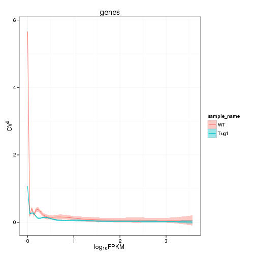

Isoforms:

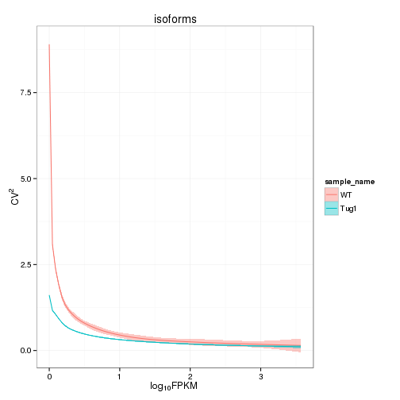

[output not shown]

### Volcano matrix (replicates)

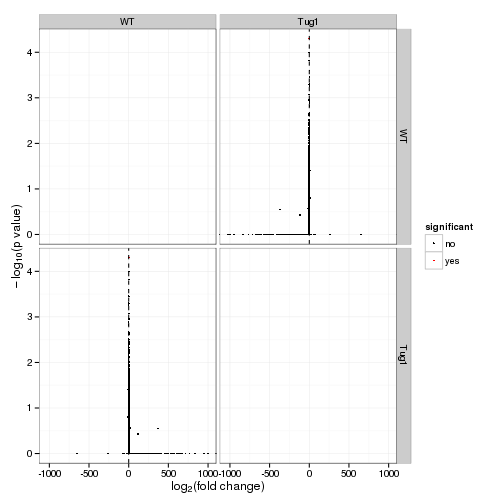

[output not shown]

[output not shown]

## Scatterplot

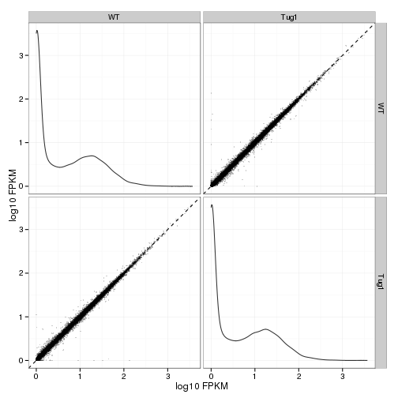

### Scatter matrix (replicates) – SKIP FOR NOW CAUSING PROBLEMS

## Distributions

### Boxplots

Boxplot (genes)

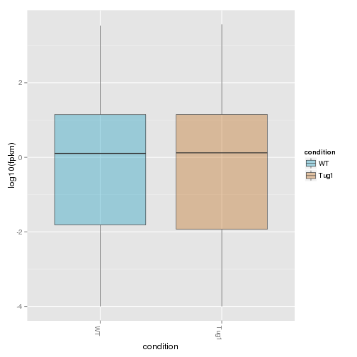

Boxplot (genes, replicates)

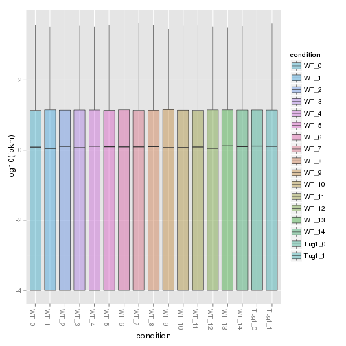

Boxplot (isoforms)

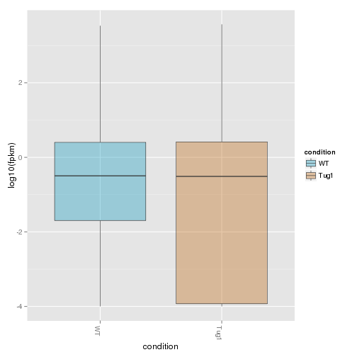

Boxplot (isoforms, replicates)

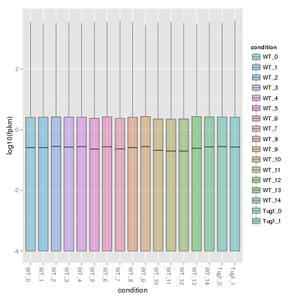

### Density

Density (genes)

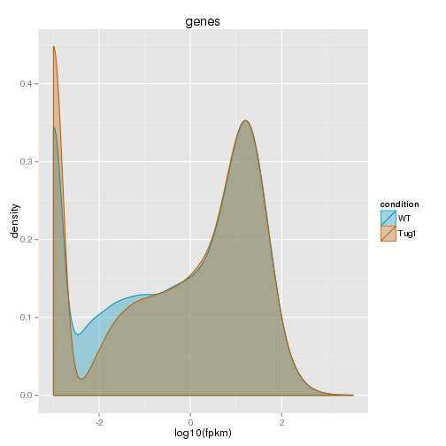

Density (genes, replicates)

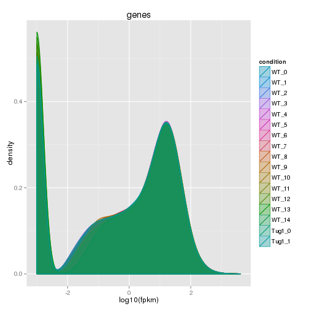

## Clustering

### Replicate Clusters

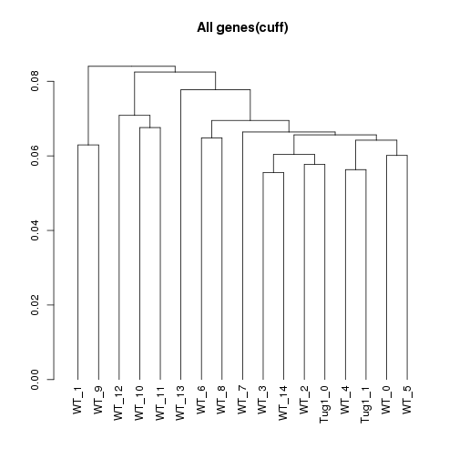

```
## 'dendrogram' with 2 branches and 17 members total, at height 0.08402
```

### PCA (genes)

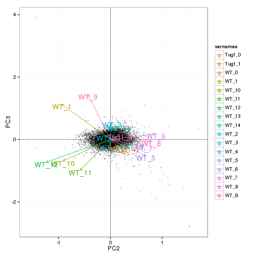

### MDS (genes)

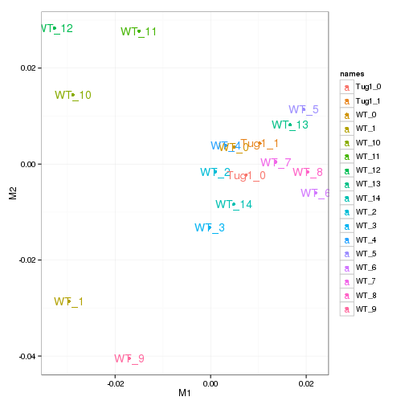

# KO assessment

## Endogenous lncRNA expression

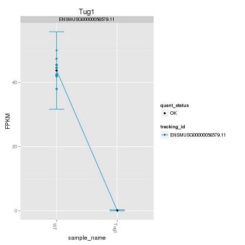

Endogenous expression of Tug1 isoforms:

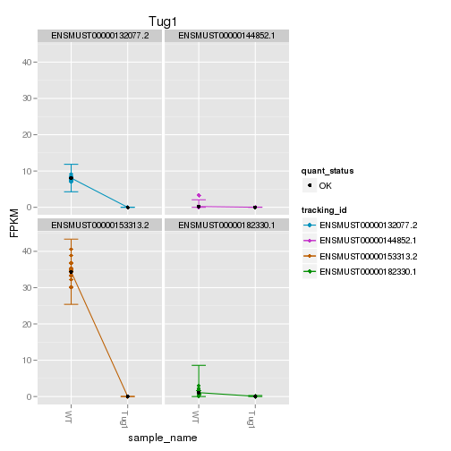

Barplot of gene expression:

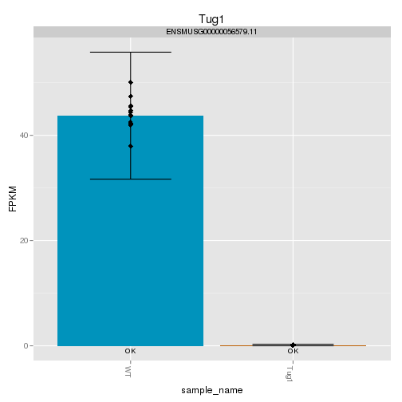

Barplot of isoform expression:

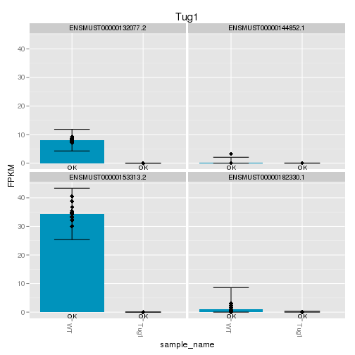

## LacZ expression

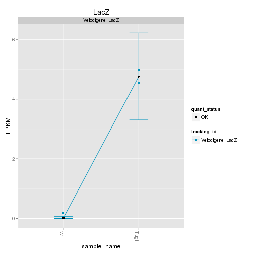

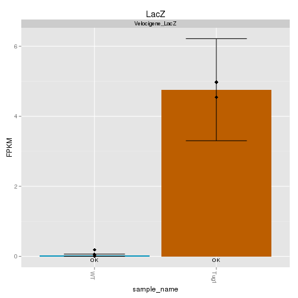

## Digital Genotyping (LacZ vs Endogenous lncRNA and Sex)

Expression plot (endogenous linc, lacZ, Y-expressed gene):

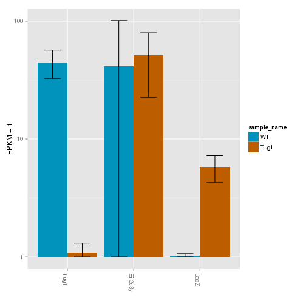

Expression heatmap:

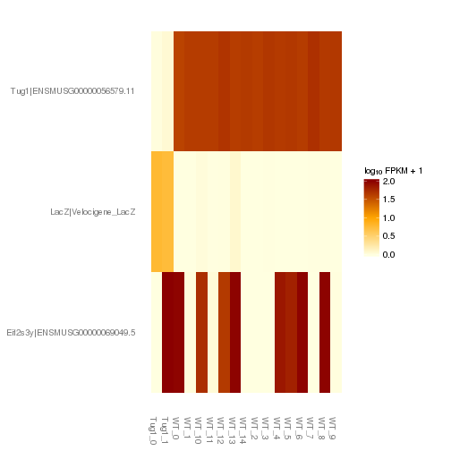

# Differential Analysis

## Differential Genes

There are 19 significantly differentially expressed genes. They are:

|  | geneAnnot$gene_short_name |
| --- | --- |
| 1 | Celsr1 |
| 2 | Rnf185 |
| 3 | Rps14 |
| 4 | Tnc |
| 5 | Morc2a |
| 6 | Inpp5j |
| 7 | 8430429K09Rik |
| 8 | Zfhx3 |
| 9 | Gm9493 |
| 10 | Fat4 |
| 11 | Map10 |
| 12 | Tug1 |
| 13 | Cox5b |
| 14 | Rps4y2 |
| 15 | Eno1 |
| 16 | Slfn9 |
| 17 | Fat1 |
| 18 | 3222401L13Rik |
| 19 | Fat3 |

### Matrix of gene significant differences between conditions

(skip for Brainmap wt-v-ko comparisons)

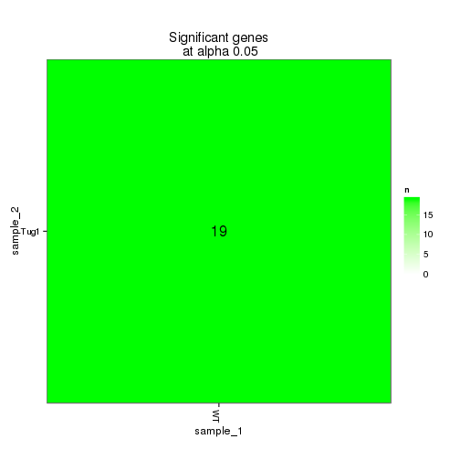

### Significant gene expression differences between conditions

Expression plot (genes):

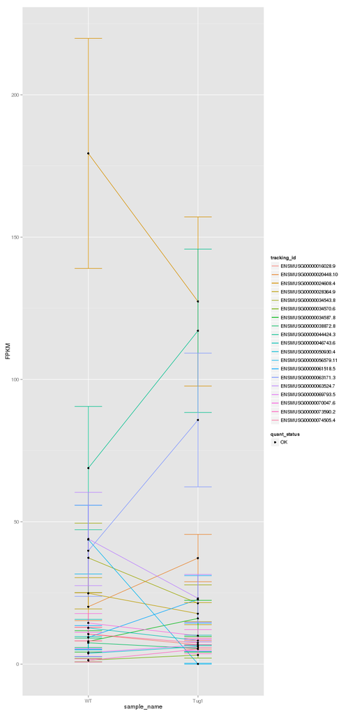

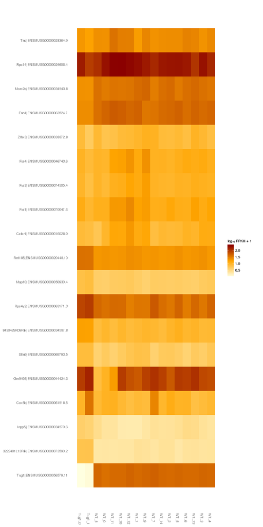

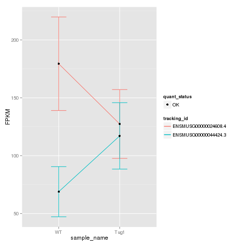

### Expression-level/significance relationship

[output not shown]

[output not shown]